# 09_pre-post-CURE-exploration

Deidre Jaeger

3/5/2020

Apple Biology It is likely/unlikely that…. Q8. Apple trees can grow from seeds as well as from attaching (grafting) a clipped branch to the base of another tree. Minor improvement

Q9. There are more than 2,500 kinds of known apple trees presently growing in the United States. Full improvement Q10. Most apple trees are self-incompatible, so you need two apple trees of the exact same kind to promote outcrossing.

Improvement Q11. Fallen fruits can lead to human/wildlife conflicts and often require city governing policies.

Minorly regressive Q12. Apple trees should be pruned to reduce disease and promote more fruit production. Minor improvement Q13. Pollinators always have a positive effect on apple trees. Minorly regressive

```r
# Q8. Apple trees can grow from seeds as well as from attaching (grafting) a clipped branch to the base of another tree.
# Q8 _ not sig
t.test(pre.post$Q8.Q13_1 ~ pre.post$type)
```

```
##
##  Welch Two Sample t-test
##
## data:  pre.post$Q8.Q13_1 by pre.post$type
## t = -0.45525, df = 21.957, p-value = 0.6534
## alternative hypothesis: true difference in means is not equal to 0
## 95 percent confidence interval:
##  -0.3496793  0.2238052
## sample estimates:
##  mean in group pre2019 mean in group post2019
##              0.8461538              0.9090909
```

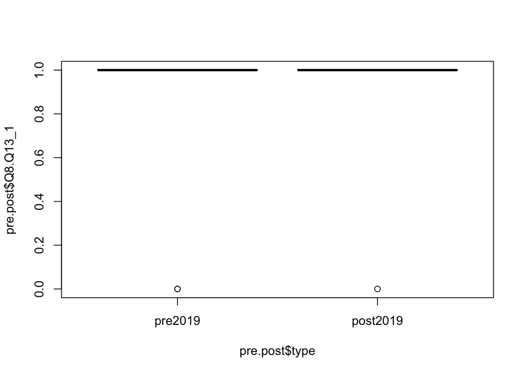

```r
boxplot(pre.post$Q8.Q13_1 ~ pre.post$type)
```

```r
# Q9. There are more than 2,500 kinds of known apple trees presently growing in the United States.
# Q9 -  not  sig
t.test(pre.post$Q8.Q13_2 ~ pre.post$type)
```

```
##
##  Welch Two Sample t-test
##
## data:  pre.post$Q8.Q13_2 by pre.post$type
## t = -1.4771, df = 12, p-value = 0.1654
## alternative hypothesis: true difference in means is not equal to 0
## 95 percent confidence interval:
##  -0.38077896  0.07308666
## sample estimates:
##  mean in group pre2019 mean in group post2019
##              0.8461538              1.0000000
```

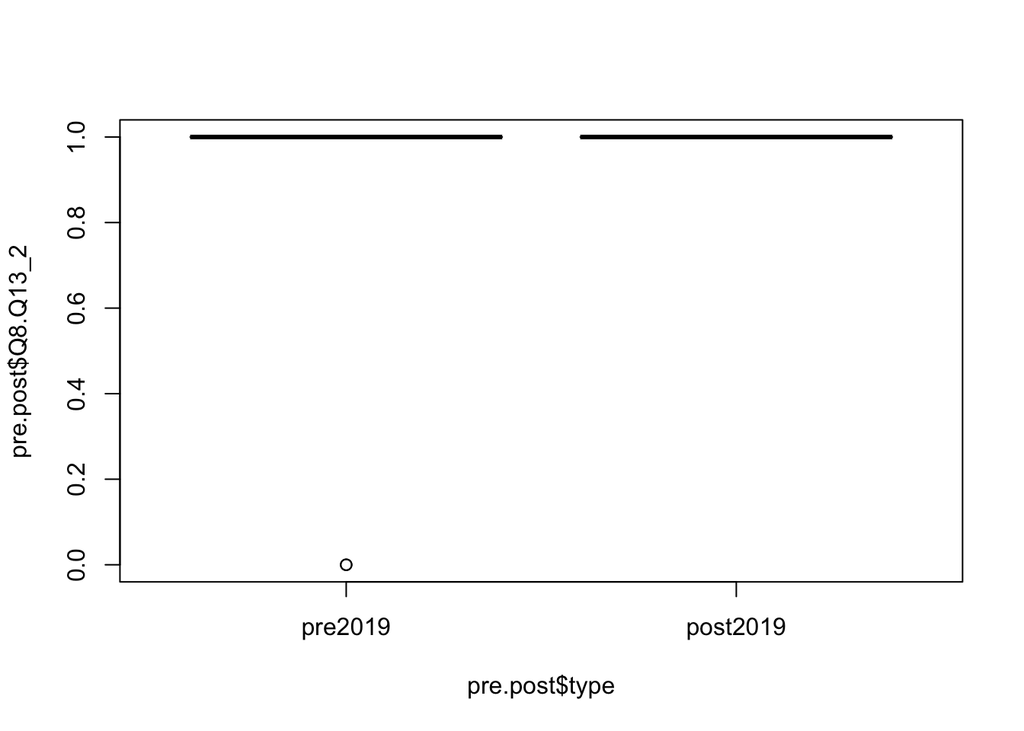

```r
boxplot(pre.post$Q8.Q13_2 ~ pre.post$type)
```

```r
# Q10. Most apple trees are self-incompatible, so you need two apple trees of the exact same kind to promote outcrossing.
# Q10 _ not sig
t.test(pre.post$Q8.Q13_3 ~ pre.post$type)
```

```
##
##  Welch Two Sample t-test
##
## data:  pre.post$Q8.Q13_3 by pre.post$type
## t = 1.0902, df = 21.946, p-value = 0.2874
## alternative hypothesis: true difference in means is not equal to 0
## 95 percent confidence interval:
##  -0.1830195  0.5886139
## sample estimates:
##  mean in group pre2019 mean in group post2019
##              0.3846154              0.1818182
```

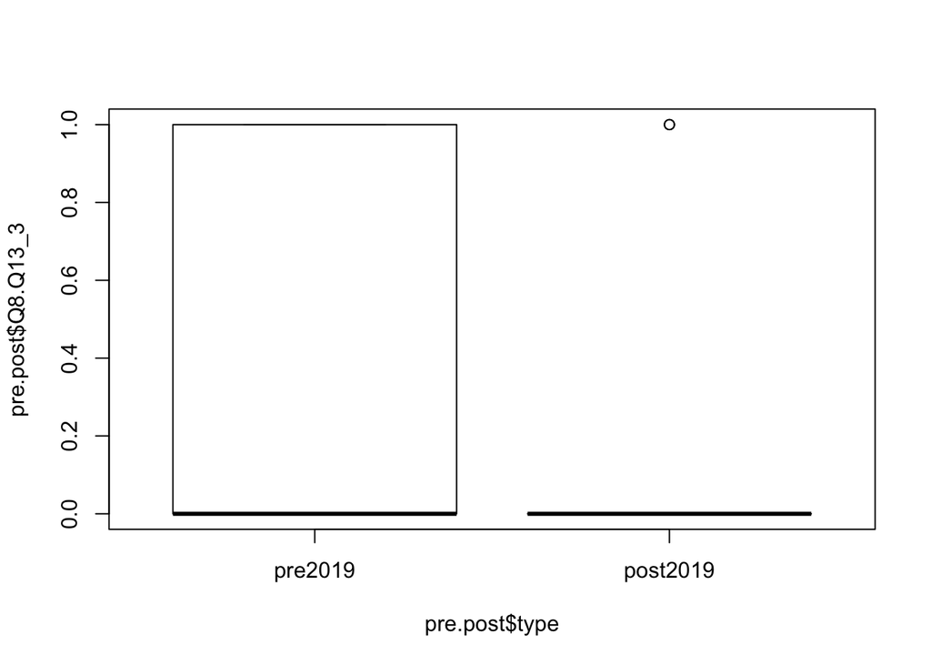

```r
boxplot(pre.post$Q8.Q13_3 ~ pre.post$type)
```

```r
# Q11. Fallen fruits can lead to human/wildlife conflicts and often require city governing policies.
# Q11 _ not sig
t.test(pre.post$Q8.Q13_4 ~ pre.post$type)
```

```
##
##  Welch Two Sample t-test
##
## data:  pre.post$Q8.Q13_4 by pre.post$type
## t = 0.72744, df = 17.262, p-value = 0.4767
## alternative hypothesis: true difference in means is not equal to 0
## 95 percent confidence interval:
##  -0.1989862  0.4087764
## sample estimates:
##  mean in group pre2019 mean in group post2019
##              0.9230769              0.8181818
```

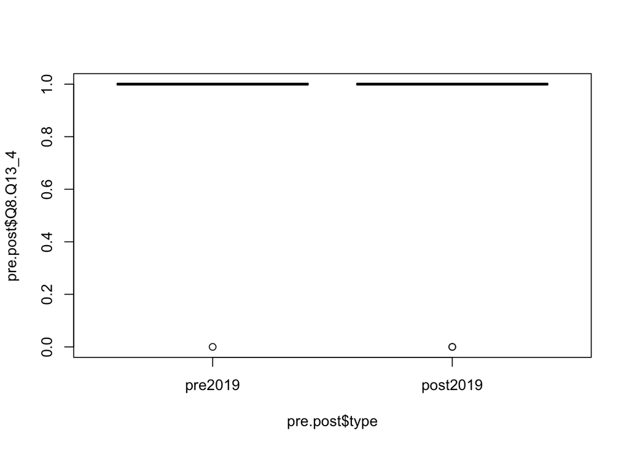

```r
boxplot(pre.post$Q8.Q13_4 ~ pre.post$type)
```

```r
# Q12. Apple trees should be pruned to reduce disease and promote more fruit production.
# Q12 _ not sig, but less variation in the post test
t.test(pre.post$Q8.Q13_5 ~ pre.post$type)
```

```
##
##  Welch Two Sample t-test
##
## data:  pre.post$Q8.Q13_5 by pre.post$type
## t = -0.28419, df = 21.807, p-value = 0.7789
## alternative hypothesis: true difference in means is not equal to 0
## 95 percent confidence interval:
##  -0.4063524  0.3084503
## sample estimates:
##  mean in group pre2019 mean in group post2019
##              0.7692308              0.8181818
```

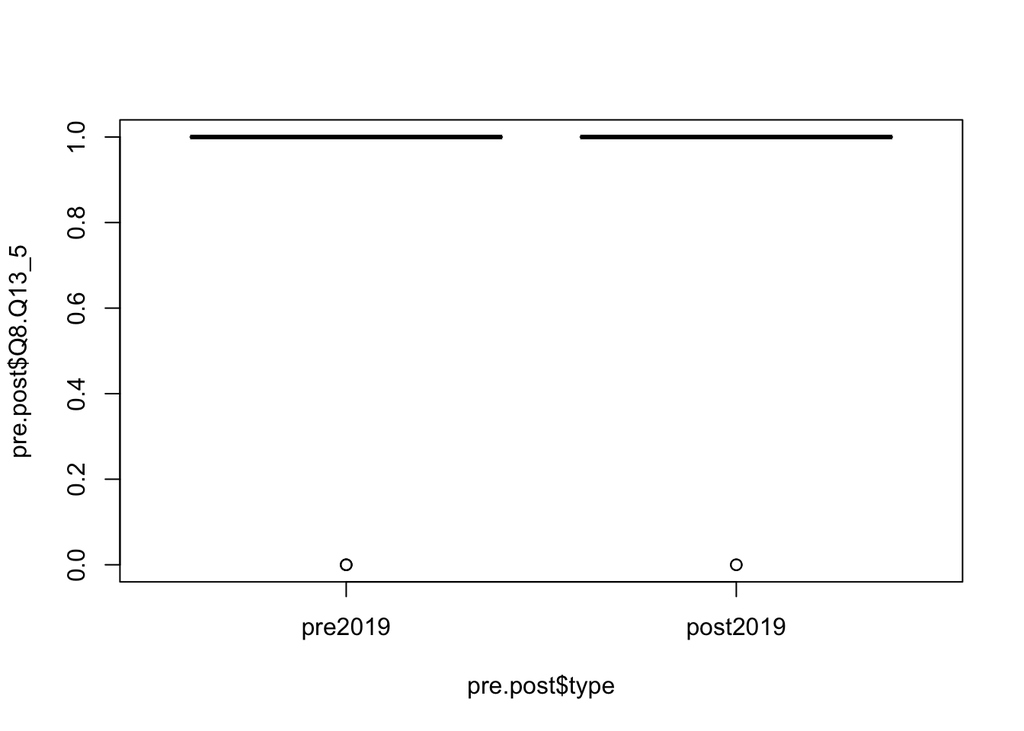

```r
boxplot(pre.post$Q8.Q13_5 ~ pre.post$type)
```

```r
# Q13. Pollinators always have a positive effect on apple trees.
# Q13 _ not sig
t.test(pre.post$Q8.Q13_6 ~ pre.post$type)
```

```
##
##  Welch Two Sample t-test
##
## data:  pre.post$Q8.Q13_6 by pre.post$type
## t = -1.2202, df = 15.693, p-value = 0.2404
## alternative hypothesis: true difference in means is not equal to 0
## 95 percent confidence interval:
##  -0.5365360  0.1449276
## sample estimates:
##  mean in group pre2019 mean in group post2019
##             0.07692308             0.27272727
```

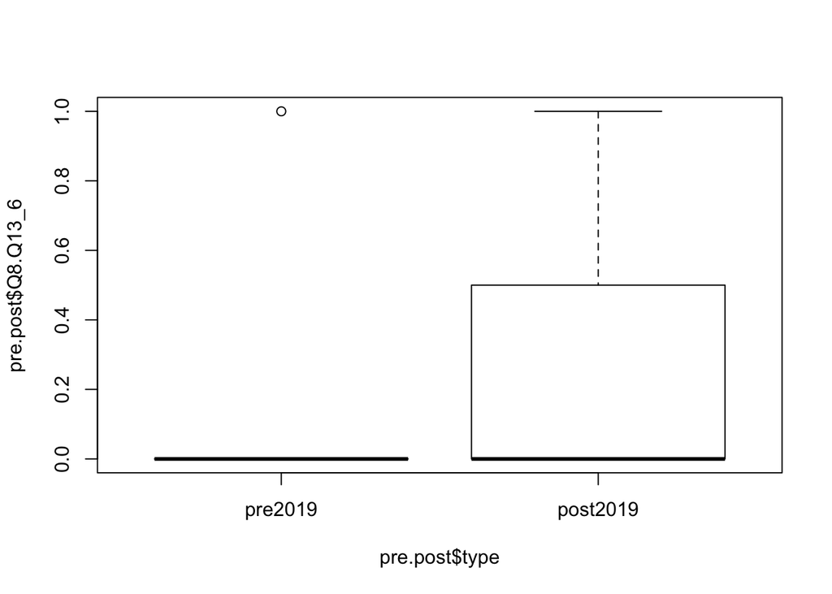

```r
boxplot(pre.post$Q8.Q13_6 ~ pre.post$type)
```

Q14. The photo above shows two branch section of tree leaves with a letter “A” and “B” labeled below each branch. Which set of leaves is most likely from an apple tree? Multiple choices: A, B, A & B, Neither A or B

```r
# Q14 _ not sig
t.test(pre.post$Q14 ~ pre.post$type)
```

```
##
##  Welch Two Sample t-test
##
## data:  pre.post$Q14 by pre.post$type
## t = 1, df = 12, p-value = 0.337
## alternative hypothesis: true difference in means is not equal to 0
## 95 percent confidence interval:
##  -0.2720337  0.7335722
## sample estimates:
##  mean in group pre2019 mean in group post2019
##               1.230769               1.000000
```

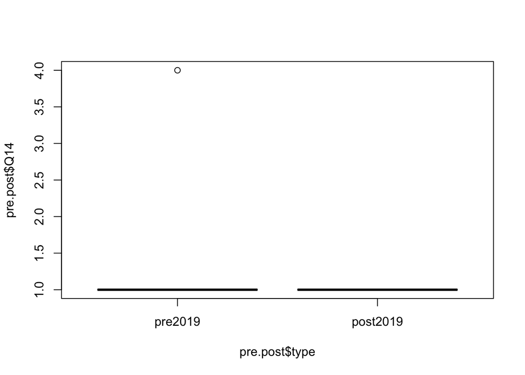

```r
boxplot(pre.post$Q14 ~ pre.post$type)
```

Place-based Ecology It is likely/unlikely that…. Q15. Most apple trees in Boulder were established through natural dispersal Q16. Apple tree survival in Boulder is most threatened by humans who want different kinds of tasting apples Q17. 6,000-19,000 lbs of apple waste may go to waste each year if Community Fruit Rescue didn’t lead community harvests Q18. Many of the oldest apple trees in Boulder are 100-150 years old and close to the end of their lifespan. Q19. Fire blight is a disease management concern for fruit trees on the Front Range.

```r
# Q15. Most apple trees in Boulder were established through natural dispersal
# Q15 _ not sig
t.test(pre.post$Q15.19_1 ~ pre.post$type)
```

```
##
##  Welch Two Sample t-test
##
## data:  pre.post$Q15.19_1 by pre.post$type
## t = 1.8974, df = 12, p-value = 0.0821
## alternative hypothesis: true difference in means is not equal to 0
## 95 percent confidence interval:
##  -0.0342312  0.4957697
## sample estimates:
##  mean in group pre2019 mean in group post2019
##              0.2307692              0.0000000
```

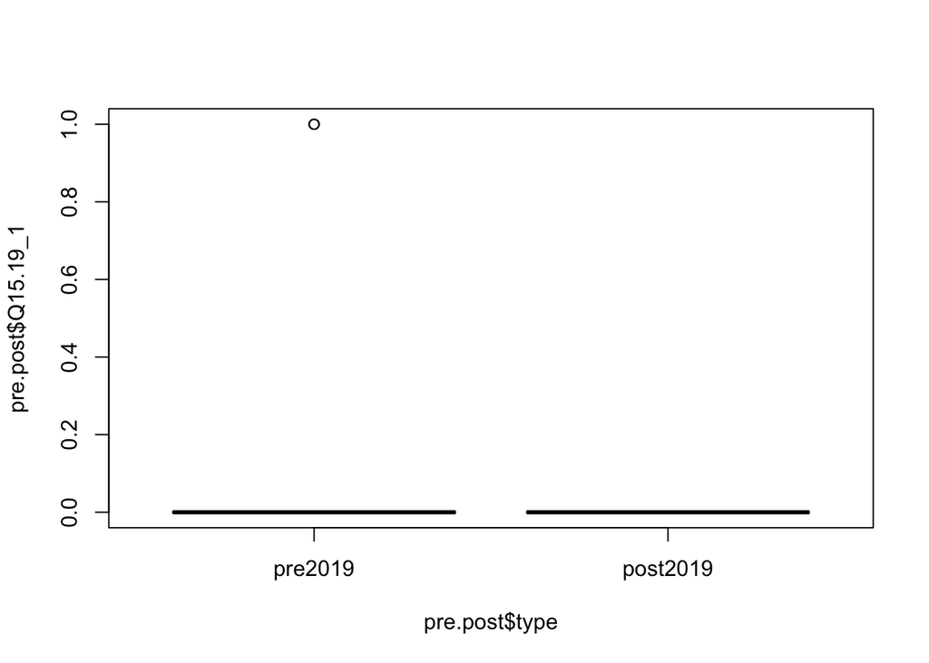

```r
boxplot(pre.post$Q15.19_1 ~ pre.post$type)
```

```r
# Q16. Apple tree survival in Boulder is most threatened by humans who want different kinds of tasting apples
# Q16 _ significant diff
t.test(pre.post$Q15.19_2 ~ pre.post$type)
```

```
##
##  Welch Two Sample t-test
##
## data:  pre.post$Q15.19_2 by pre.post$type
## t = 2.6293, df = 19.72, p-value = 0.01619
## alternative hypothesis: true difference in means is not equal to 0
## 95 percent confidence interval:
##  0.09215817 0.80294673
## sample estimates:
##  mean in group pre2019 mean in group post2019
##             0.53846154             0.09090909
```

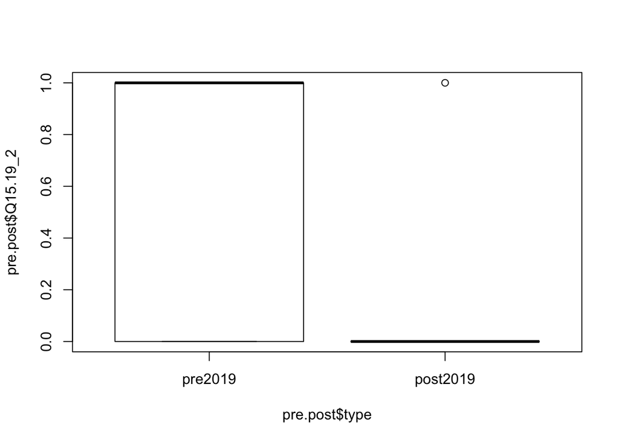

```r
boxplot(pre.post$Q15.19_2 ~ pre.post$type)
```